# NOAA Temperature Data

Data for Eastern Shore Region

Tolu Odukoya

7/4/2021

## Data Source

Source: NOAA’s Climate Divisional Database (nClimDiv), June 2021 release

- Download URL: https://www.ncei.noaa.gov/pub/data/cirs/climdiv/counties.zip
- Download URL: https://www.ncei.noaa.gov/pub/data/cirs/climdiv/climdiv-tmaxcy-v1.0.0-20210604

### The Data Used Here

The Climate Divisional Dataset from the National Center For Environmental Information began as the only long-term temporally and spatially complete dataset from which to generate historical climate analyses (1895-2013) for the contiguous United States (CONUS). It was originally developed for climate division, statewide, regional, national, and population-weighted monitoring of drought, temperature, precipitation, and heating/cooling degree day values.

There are 344 climate divisions in the CONUS. For each climate division, monthly station temperature and precipitation values are computed from the daily observations. The divisional values are weighted by area to compute statewide values and the statewide values are weighted by area to compute regional values. (Karl and Koss, 1984).

The data here is the county data from all the states in the contigous United States. While NOAA includes information on a variety of climate measures, we are focusing on the maximum temperature of the counties of interest.

To Learn More, See:

- [National Center For Environmental Information and Data](https://www.ncdc.noaa.gov/monitoring-references/maps/us-climate-divisions.php#grdd)

## Variable Descriptions

```r
glimpse(eastern_sf1)
```

```
## Rows: 252
## Columns: 23
## $ NAME       <chr> "Accomack", "Accomack", "Accomack", "Accomack", "Accomack",…
## $ Year       <dbl> 1895, 1896, 1897, 1898, 1899, 1900, 1901, 1902, 1903, 1904,…
## $ CNTY_FIPS  <chr> "001", "001", "001", "001", "001", "001", "001", "001", "00…
## $ X          <dbl> -75.66484, -75.66484, -75.66484, -75.66484, -75.66484, -75.…
## $ Y          <dbl> 37.76368, 37.76368, 37.76368, 37.76368, 37.76368, 37.76368,…
## $ STATE_FIPS <chr> "51", "51", "51", "51", "51", "51", "51", "51", "51", "51",…
## $ FIPS       <chr> "51001", "51001", "51001", "51001", "51001", "51001", "5100…
## $ AREA       <dbl> 415.34, 415.34, 415.34, 415.34, 415.34, 415.34, 415.34, 415…
## $ Jan        <dbl> 43.1, 42.8, 42.1, 48.1, 46.3, 46.0, 43.8, 41.3, 44.2, 42.7,…
## $ Feb        <dbl> 34.1, 45.9, 45.4, 46.8, 37.5, 45.2, 38.6, 37.7, 48.6, 38.6,…
## $ Mar        <dbl> 49.5, 48.9, 55.7, 57.9, 51.4, 48.4, 54.2, 55.3, 58.6, 50.8,…
## $ Apr        <dbl> 61.3, 63.7, 63.1, 58.3, 63.1, 60.9, 55.9, 60.1, 61.4, 59.4,…
## $ May        <dbl> 68.6, 75.8, 70.6, 70.1, 71.9, 73.6, 69.1, 71.9, 72.5, 73.4,…
## $ Jun        <dbl> 81.8, 78.8, 76.7, 79.1, 83.2, 80.5, 79.8, 80.3, 74.0, 79.4,…
## $ Jul        <dbl> 82.8, 85.9, 82.6, 83.7, 85.3, 87.5, 87.2, 85.6, 85.6, 83.0,…
## $ Aug        <dbl> 87.4, 86.3, 82.4, 84.6, 82.2, 87.6, 83.3, 82.0, 80.6, 81.2,…
## $ Sep        <dbl> 83.0, 76.1, 80.2, 78.8, 77.3, 81.6, 77.5, 75.7, 76.6, 77.9,…
## $ Oct        <dbl> 64.0, 64.4, 68.6, 69.7, 69.2, 70.9, 67.5, 69.6, 68.1, 65.9,…
## $ Nov        <dbl> 57.8, 63.1, 59.9, 55.6, 58.4, 59.5, 50.4, 61.2, 55.5, 52.9,…
## $ Dec        <dbl> 49.6, 46.2, 49.5, 50.0, 49.1, 47.5, 46.5, 46.4, 45.2, 41.2,…
## $ Avg_Temp   <dbl> 63.58333, 64.82500, 64.73333, 65.22500, 64.57500, 65.76667,…
## $ Fipsyear   <dbl> 44001271895, 44001271896, 44001271897, 44001271898, 4400127…
## $ geometry   <MULTIPOLYGON [°]> MULTIPOLYGON (((-75.32379 3..., MULTIPOLYGON (…
```

Observations are county level estimates of…

- Monthly maximum temperature of each county for years 1895-2021
- Yearly average maximum temperature for each county for those years.

## Summaries

5-number summaries of (non-missing) numeric variables (remove non-numeric observations)

```r
noaa %>% select(-c(CNTY_FIPS, Fipsyear, Year)) %>%
  select(where(~is.numeric(.x) && !is.na(.x))) %>%
  as.data.frame() %>%
  stargazer(., type = "text", title = "Summary Statistics", digits = 0,
            summary.stat = c("mean", "sd", "min", "median", "max"))
```

```
##
## Summary Statistics
## ======================================
## Statistic Mean St. Dev. Min Median Max
## --------------------------------------
## Jan        46     5     33    46   59
## Feb        47     5     34    48   59
## Mar        55     4     42    55   67
## Apr        64     3     55    64   72
## May        73     3     67    73   81
## Jun        81     2     73    81   88
## Jul        86     2     81    86   91
## Aug        84     2     78    84   89
## Sep        79     2     72    79   85
## Oct        69     3     64    69   77
## Nov        59     3     49    58   65
## Dec        49     4     38    50   62
## Avg_Temp   66     2     59    66   70
## --------------------------------------
```

## Maps

### Maximum Temperature in July across Counties for all Years

```r
eastern_sf1a <-
  ggplot(eastern_sf1) +
  geom_sf(aes(fill = Jul), color = "black", alpha = .9, na.rm = TRUE) +
   geom_text_repel(data = eastern_sf1, aes(X, Y, label = NAME), size = 4, nudge_x = 1, nudge_y = 0, fontface = "bold", hjust = 0.9) +
  scale_fill_fermenter(palette = "YlOrRd", direction = 1,   type = "seq", n.breaks = 7) +
     theme_void() +
  guides(fill =
           guide_colourbar(title.position="top", title.hjust = 0.5,
                           barwidth = 1)
  )  +
  labs(fill = "Temperature ", title = 'Year: {frame_time}',
       caption = "Maximum Temperature in July for Eastern Shore Counties") +
 transition_time(as.integer(Year)) +
ease_aes('linear')
```

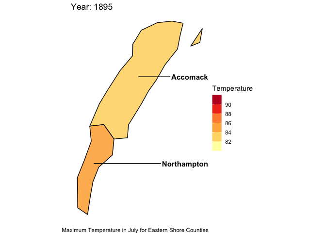

```r
animate(eastern_sf1a, fps = 1, detail = 1, nframes = 127)
```

```r
meta %>%
  filter(varname == "Jul") %>%
  select(about) %>%
  as.list()
```

$about [1] “Monthly Divisional Temperature format (f7.2) Range of values -50.00 to 140.00 degrees Fahrenheit. Decimals retain a position in the 7-character field. Missing values in the latest year are indicated by -99.99. Missing values removed for visualization, resulting in no plots for 2021”

#### Warming Stripes Showing Maximum Temperature in July across Counties for all Years

##### Accomack County

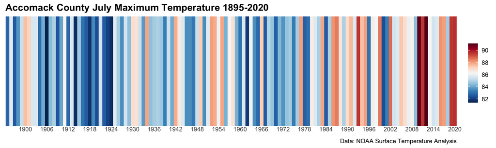

```r
 ggplot(eastern_sf1_jla,
             aes(x = date, y = 1, fill = ta))+
        geom_tile()+
           scale_x_date(date_breaks = "6 years",
                     date_labels = "%Y",
                     expand = c(0, 0))+
           scale_y_continuous(expand = c(0, 0))+
           scale_fill_gradientn(colors = rev(col_strip))+
             guides(fill = guide_colorbar(barwidth = 1))+
            labs(title = "Accomack County July Maximum Temperature 1895-2020",
                caption = "Data: NOAA Surface Temperature Analysis")+
              theme_strip
```

##### Northampton County

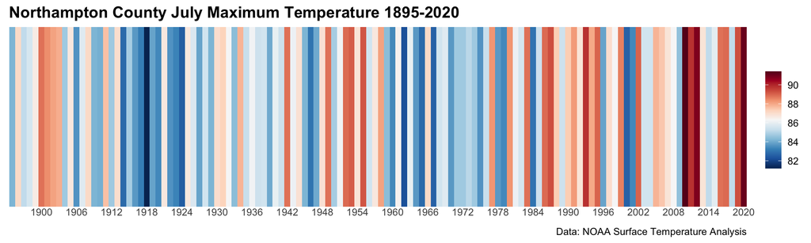

```r
 ggplot(eastern_sf1_jln,
             aes(x = date, y = 1, fill = ta))+
        geom_tile()+
           scale_x_date(date_breaks = "6 years",
                     date_labels = "%Y",
                     expand = c(0, 0))+
           scale_y_continuous(expand = c(0, 0))+
           scale_fill_gradientn(colors = rev(col_strip))+
             guides(fill = guide_colorbar(barwidth = 1))+
            labs(title = "Northampton County July Maximum Temperature 1895-2020",
                caption = "Data: NOAA Surface Temperature Analysis")+
              theme_strip
```

### Average Yearly Maximum Temperature across Counties

```r
eastern_sf1b <-
  ggplot(eastern_sf1) +
  geom_sf(aes(fill = Avg_Temp), color = "black", alpha = .9, na.rm = TRUE) +
   geom_text_repel(data = eastern_sf1, aes(X, Y, label = NAME), size = 4, nudge_x = 1, nudge_y = 0, fontface = "bold", hjust = 0.9) +
  scale_fill_fermenter(palette = "BuPu", direction = 1,   type = "seq", n.breaks = 6) +
     theme_void() +
  guides(fill =
           guide_colourbar(title.position="top", title.hjust = 0.5,
                           barwidth = 1)
  )  +
  labs(fill = "Temperature ", title = 'Year: {frame_time}',
       caption = "Average Yearly Maximum Temperature For Eastern Shore Counties") +
 transition_time(as.integer(Year)) +
ease_aes('linear')
```

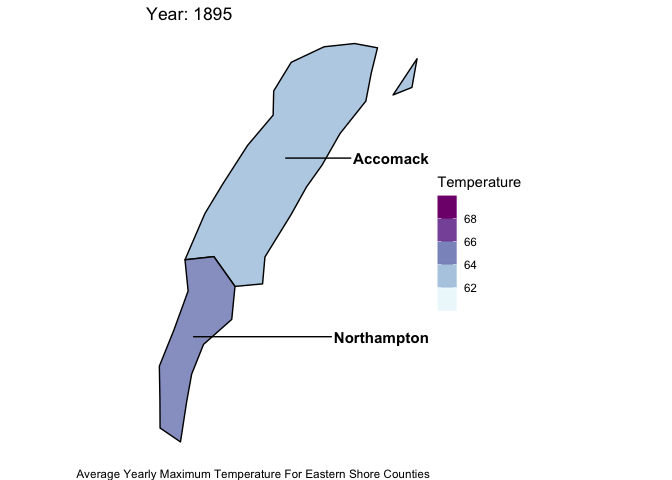

```r
animate(eastern_sf1b, fps = 1, detail = 1, nframes = 127)
```

```r
meta %>%
  filter(varname == "Avg_Temp") %>%
  select(about) %>%
  as.list()
```

$about [1] “Average yearly temperature for each county. Created by suming the maximum temperature for each month, for each county, and taking the mean. NA’s for months in 2021 not currently available were removed and the mean calculated for the 6 months so far. Missing values removed for visualization, resulting in no plots for 2021”

#### Warming Stripes Showing Average Yearly Temperature across Counties

##### Accomack County

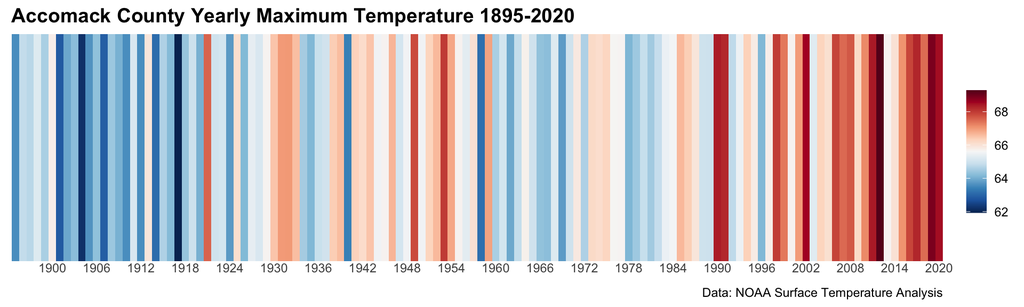

```r
 ggplot(eastern_sf1_yra,
             aes(x = date, y = 1, fill = ta))+
        geom_tile()+
           scale_x_date(date_breaks = "6 years",
                     date_labels = "%Y",
                     expand = c(0, 0))+
           scale_y_continuous(expand = c(0, 0))+
           scale_fill_gradientn(colors = rev(col_strip))+
             guides(fill = guide_colorbar(barwidth = 1))+
            labs(title = "Accomack County Yearly Maximum Temperature 1895-2020",
                caption = "Data: NOAA Surface Temperature Analysis")+
              theme_strip
```

##### Northampton County

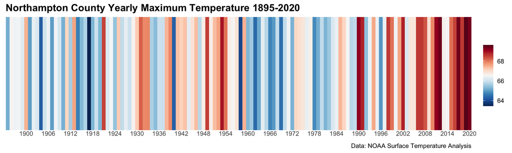

```r
 ggplot(eastern_sf1_yrn,
             aes(x = date, y = 1, fill = ta))+
        geom_tile()+
           scale_x_date(date_breaks = "6 years",
                     date_labels = "%Y",
                     expand = c(0, 0))+
           scale_y_continuous(expand = c(0, 0))+
           scale_fill_gradientn(colors = rev(col_strip))+
             guides(fill = guide_colorbar(barwidth = 1))+
            labs(title = "Northampton County Yearly Maximum Temperature 1895-2020",
                caption = "Data: NOAA Surface Temperature Analysis")+
              theme_strip
```